# Practical Machine Learning Course Project

Derek Bryant

March 3, 2019

## Introduction

The basic goal of the project was to predit the manner in which the exercise was done in a set of 20 cases. Provided was a dataset with 20 cases and a larger dataset from which models were developed.

Not all code ran is shown as indicated in the assignment there is security concerns with doing so.

## Acquire and clean data

The steps taken to clean the data included the omission of the omission of variables that summerized or aggrated parameters from the devices.

There were two data sets loaded from downloaded data: A set to build the model with and twenty cases to use to test the method. The model building set was split into two to create a testing and validation set.

## Model Selection and Creation

That first model types that came to mind to predict the classe (catergory) was dendrograms. In my case I started with the a method using the r package “rpart” then found that a random forest would be more accurate.

## Cross Validation

The annotation on the second plot shows that the accuracy of the random forest model was more favorable.

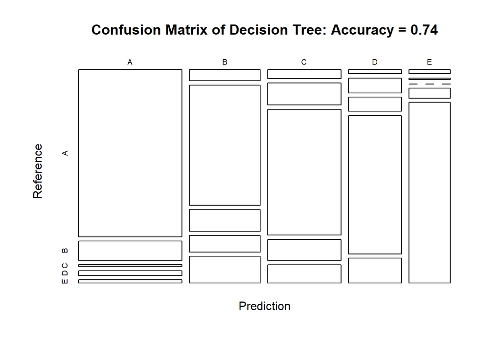

```r
plot(confMtrx$table,
     col = confMtrx$byClass,
     main = paste(
       "Confusion Matrix of Decision Tree: Accuracy =",
       round(confMtrx$overall["Accuracy"],2)
     ))
```

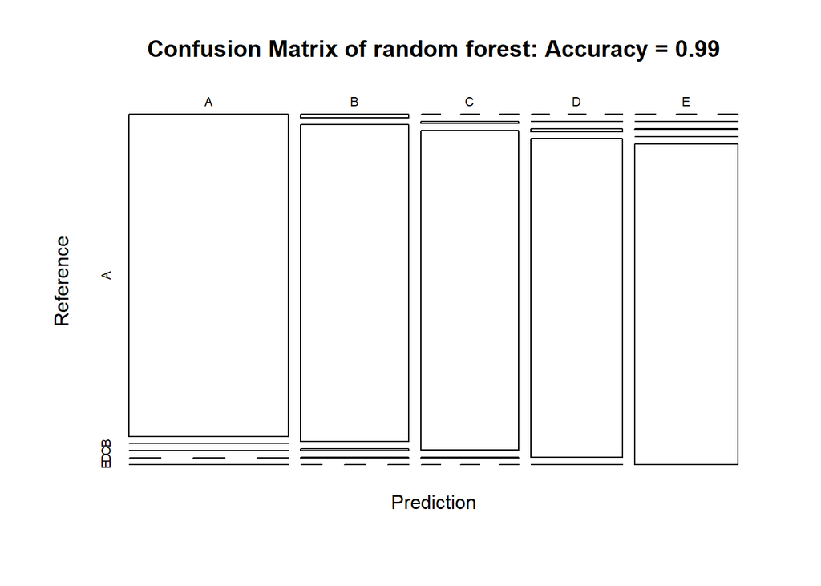

```r
plot(confMtrx_rf$table,
     col = confMtrx$byClass,
     main = paste(
       "Confusion Matrix of random forest: Accuracy =",
       round(confMtrx_rf$overall["Accuracy"],2)
     ))
```

The results of the random forest follow, as does the indication that the accuracy maximizes at 25 of the predictors.

```r
#print out modRF to see the random forest modeling result.
modRF
```

```
## Random Forest
##
## 9812 samples
##   48 predictor
##    5 classes: 'A', 'B', 'C', 'D', 'E'
##
## No pre-processing
## Resampling: Cross-Validated (5 fold)
## Summary of sample sizes: 7849, 7850, 7849, 7849, 7851
## Resampling results across tuning parameters:
##
##   mtry  Accuracy   Kappa
##    2    0.9859357  0.9822074
##   25    0.9866495  0.9831131
##   48    0.9803311  0.9751213
##
## Accuracy was used to select the optimal model using the largest value.
## The final value used for the model was mtry = 25.
```

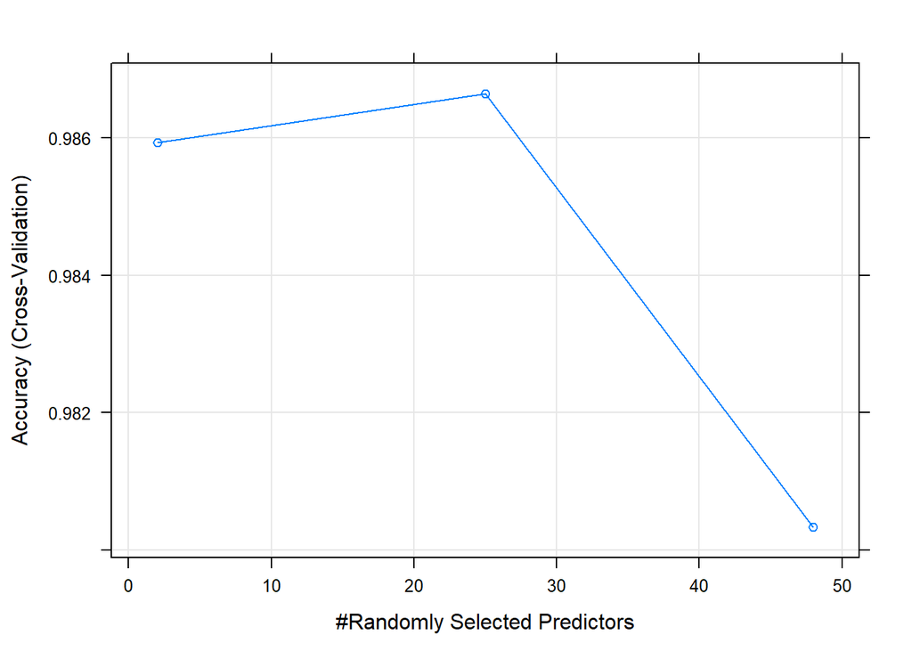

```r
plot(modRF)
```

## Expected out of sample error

```r
sample_accuracy <- postResample(pred_RandomForest_VALIDATION,
                                training_set_VALIDATION$classe)

sample_accuracy
```

```
##  Accuracy     Kappa
## 0.9922528 0.9901991
```

```r
errorRate <- 1 - as.numeric(
  confusionMatrix(
    training_set_VALIDATION$classe, pred_RandomForest_VALIDATION)$overall[1]
  )
errorRate
```

```
## [1] 0.007747197
```

## Outcome of Model using test data

```r
predict(modRF, testing_set)
```

```
##  [1] B A B A A E D B A A B C B A E E A B B B
## Levels: A B C D E
```